# Analiza Sklepu Rowerowego

# Przypisywanie zmiennych typu factor

W celu poprawności analiz dokonano konwersji wybranych kolumn na zmienne kategoryczne (factor), obejmujących m.in. stan cywilny, płeć, wykształcenie, zawód, status własności nieruchomości, dystans do pracy, region oraz decyzję o zakupie roweru. Przekształcenie to umożliwia poprawne traktowanie danych przez R jako nominalne lub porządkowe, co jest istotne dla analiz statystycznych, modeli predykcyjnych oraz wizualizacji.

```r
sklep_rowerowy <- sklep_rowerowy %>%
  mutate(
    `Marital.Status` = na_if(`Marital.Status`, ""),
    Gender = na_if(Gender, ""),
    `Home.Owner` = na_if(`Home.Owner`, ""),
    `Marital.Status` = factor(`Marital.Status`),
    Gender = factor(Gender),
    Education = factor(Education),
    Occupation = factor(Occupation),
    `Home.Owner` = factor(`Home.Owner`),
    `Commute.Distance` = factor(`Commute.Distance`),
    Region = factor(Region),
    `Purchased.Bike` = factor(`Purchased.Bike`)
  )
```

# Imputacja Danych

W celu uzupełnienia brakujących wartości w zbiorze “sklep_rowerowy” zastosowano średnią adaptacyjną do zmiennych liczbowych oraz metodę Predictive Mean Matching (pmm) dla zmiennych kategorycznych. Imputacja pozwoliła na eliminację braków danych, co zwiększa kompletność i wiarygodność zbioru, umożliwiając dokładniejsze analizy. Dzięki tym metodom zachowano strukturę danych, minimalizując wpływ braków na wyniki statystyczne i modele predykcyjne. Wizualizacja potwierdza, że po imputacji wszystkie kolumny są w pełni uzupełnione (0% braków).

```r
sklep_rowerowy <- sklep_rowerowy %>%
mutate(across(where(is.numeric), ~ ifelse(is.na(.), mean(., na.rm = TRUE, trim = 0.1), .)))

imputed_data <- mice(sklep_rowerowy, m = 5, method = 'pmm', seed = 123)
sklep_rowerowy <- complete(imputed_data)

sklep_rowerowy

n_miss(sklep_rowerowy)
```

```
## [1] 0
```

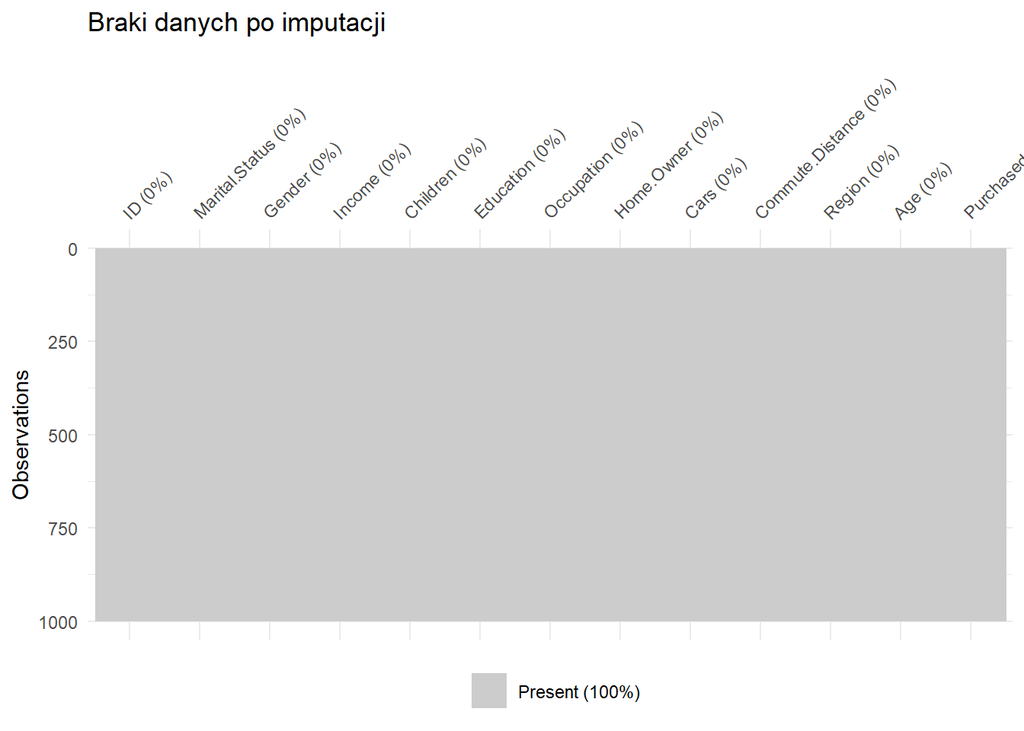

```r
vis_miss(sklep_rowerowy) + labs(title = "Braki danych po imputacji")
```

## Wizualizacje

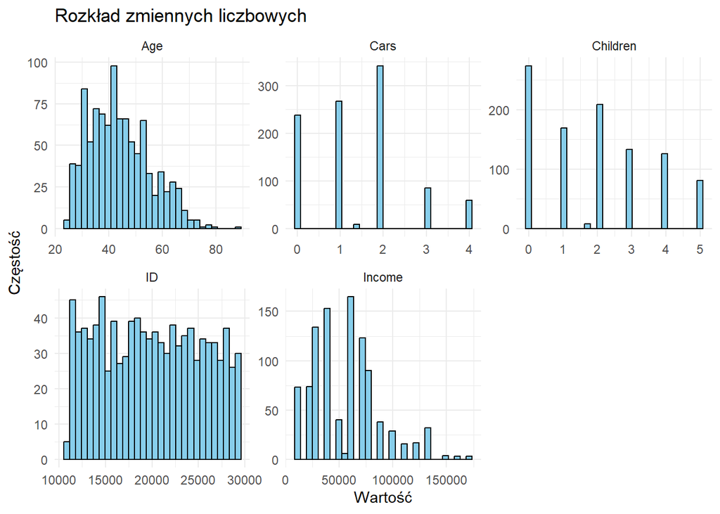

```r
sklep_rowerowy %>%
select(where(is.numeric)) %>%
pivot_longer(everything()) %>%
ggplot(aes(x = value)) +
geom_histogram(bins = 30, fill = "skyblue", color = "black") +
facet_wrap(~ name, scales = "free") +
labs(title = "Rozkład zmiennych liczbowych", x = "Wartość", y = "Częstość") +
theme_minimal()
```

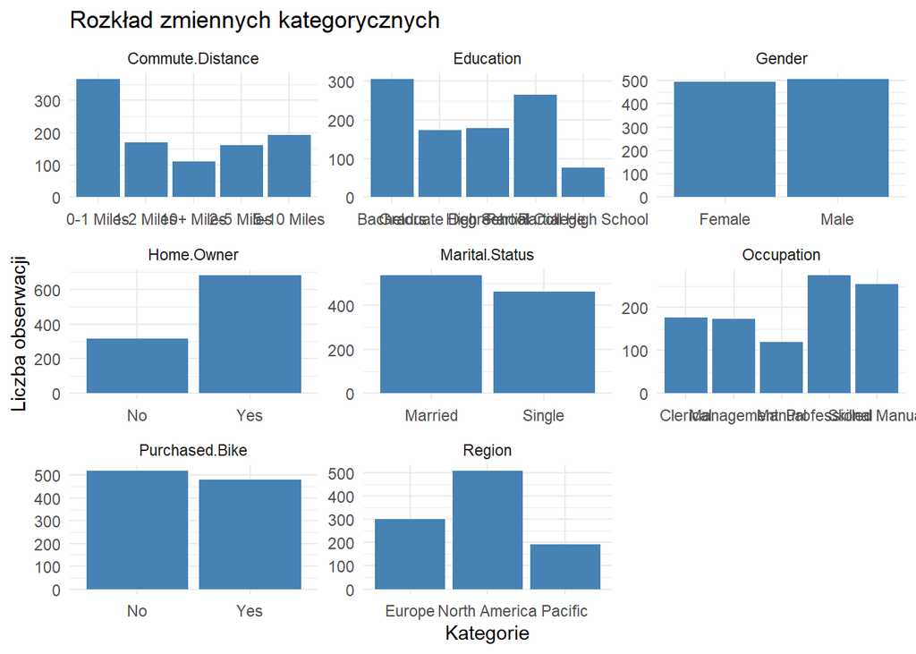

```r
sklep_rowerowy %>%
select(where(is.factor)) %>%
pivot_longer(everything()) %>%
ggplot(aes(x = value)) +
geom_bar(fill = "steelblue") +
facet_wrap(~ name, scales = "free") +
labs(title = "Rozkład zmiennych kategorycznych", x = "Kategorie", y = "Liczba obserwacji") +
theme_minimal()
```

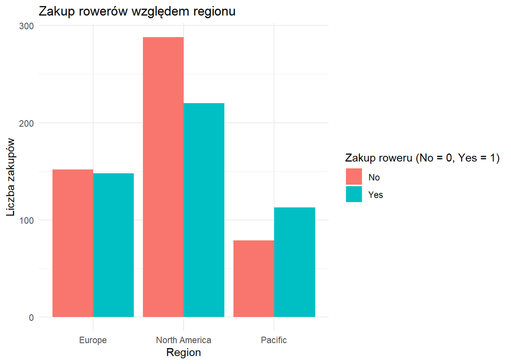

```r
  ggplot(sklep_rowerowy, aes(x = Region, fill = Purchased.Bike)) +
    geom_bar(position = "dodge") +
    labs(title = "Zakup rowerów względem regionu",
         x = "Region",
         y = "Liczba zakupów",
         fill = "Zakup roweru (No = 0, Yes = 1)") +
    theme_minimal()
```

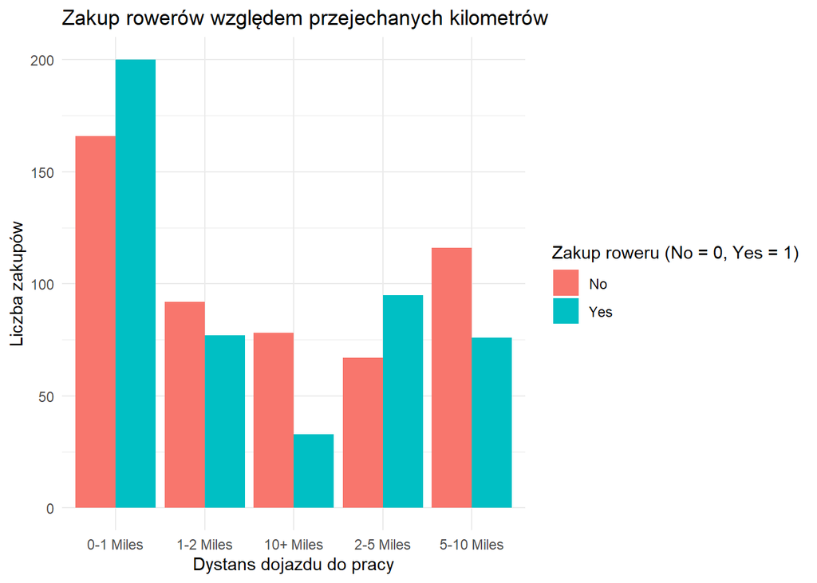

```r
ggplot(sklep_rowerowy, aes(x = Commute.Distance, fill = Purchased.Bike)) +
  geom_bar(position = "dodge") +
  labs(title = "Zakup rowerów względem przejechanych kilometrów",
       x = "Dystans dojazdu do pracy",
       y = "Liczba zakupów",
       fill = "Zakup roweru (No = 0, Yes = 1)") +
  theme_minimal()
```

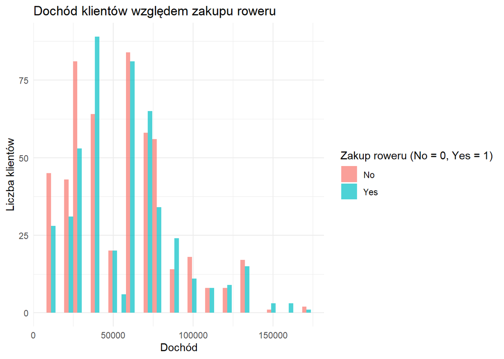

```r
ggplot(sklep_rowerowy, aes(x = Income, fill = Purchased.Bike)) +
  geom_histogram(position = "dodge", bins = 30, alpha = 0.7) +
  labs(title = "Dochód klientów względem zakupu roweru",
       x = "Dochód",
       y = "Liczba klientów",
       fill = "Zakup roweru (No = 0, Yes = 1)") +
  theme_minimal()
```

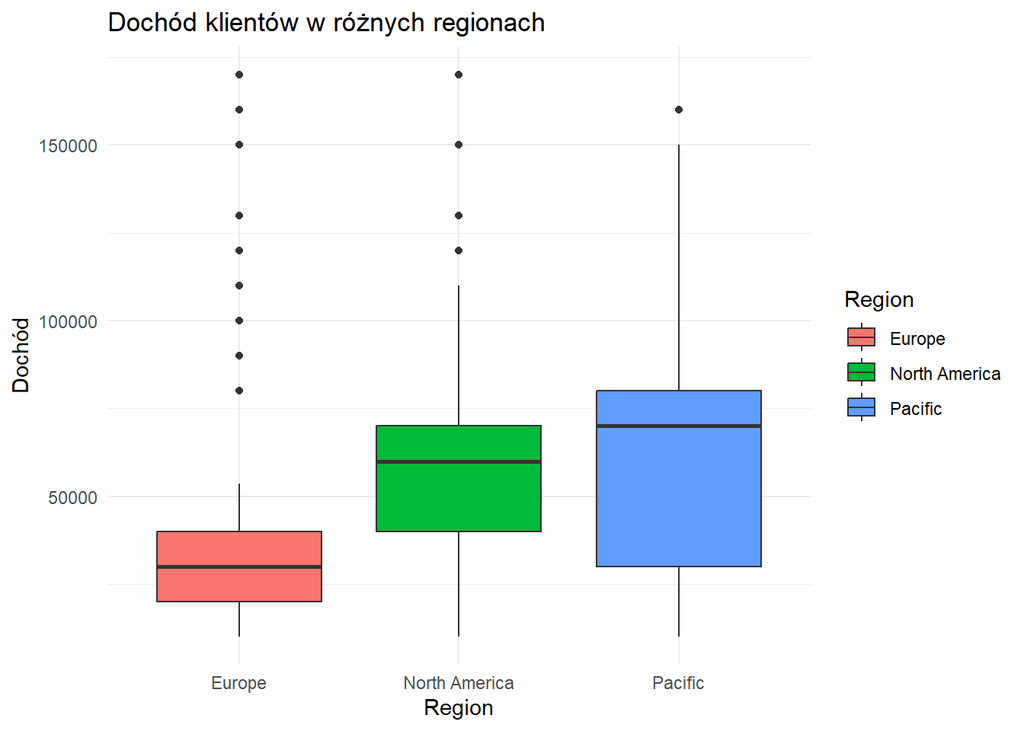

```r
ggplot(sklep_rowerowy, aes(x = Region, y = Income, fill = Region)) +
  geom_boxplot() +
  labs(title = "Dochód klientów w różnych regionach",
       x = "Region",
       y = "Dochód") +
  theme_minimal()
```

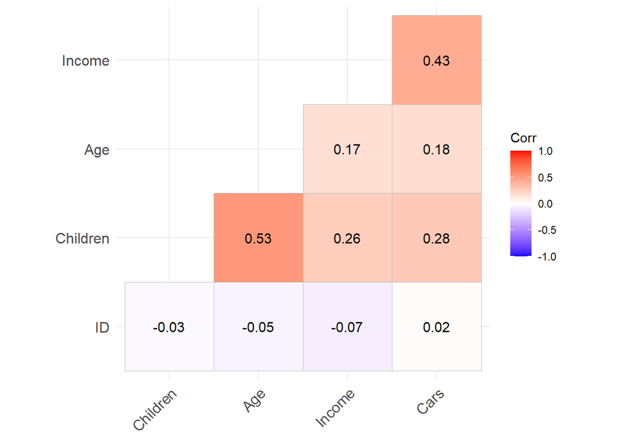

```r
cor_matrix <- cor(sklep_rowerowy %>% select(where(is.numeric)), use = "complete.obs")
ggcorrplot(cor_matrix, hc.order = TRUE, type = "lower", lab = TRUE)
```

## Model drzewa decyzyjnego

```r
set.seed(123)
train_index <- sample(seq_len(nrow(sklep_rowerowy)), size = 0.7 * nrow(sklep_rowerowy))
train_data <- sklep_rowerowy[train_index, ]
test_data <- sklep_rowerowy[-train_index, ]

tree_model <- rpart(`Purchased.Bike` ~ ., data = train_data, method = "class")
tree_model
```

```
## n= 700
##
## node), split, n, loss, yval, (yprob)
##       * denotes terminal node
##
##   1) root 700 333 No (0.52428571 0.47571429)
##     2) Cars>=1.184741 337 121 No (0.64094955 0.35905045)
##       4) ID>=18668.5 195  56 No (0.71282051 0.28717949) *
##       5) ID< 18668.5 142  65 No (0.54225352 0.45774648)
##        10) Children>=4.5 25   6 No (0.76000000 0.24000000) *
##        11) Children< 4.5 117  58 Yes (0.49572650 0.50427350)
##          22) Occupation=Clerical,Management 37  11 No (0.70270270 0.29729730) *
##          23) Occupation=Manual,Professional,Skilled Manual 80  32 Yes (0.40000000 0.60000000) *
##     3) Cars< 1.184741 363 151 Yes (0.41597796 0.58402204)
##       6) ID< 17728 140  61 No (0.56428571 0.43571429)
##        12) Occupation=Management,Manual,Skilled Manual 74  22 No (0.70270270 0.29729730) *
##        13) Occupation=Clerical,Professional 66  27 Yes (0.40909091 0.59090909)
##          26) Age< 33.5 10   2 No (0.80000000 0.20000000) *
##          27) Age>=33.5 56  19 Yes (0.33928571 0.66071429)
##            54) Age>=54.5 8   2 No (0.75000000 0.25000000) *
##            55) Age< 54.5 48  13 Yes (0.27083333 0.72916667) *
##       7) ID>=17728 223  72 Yes (0.32286996 0.67713004)
##        14) Age< 31.5 30  11 No (0.63333333 0.36666667)
##          28) Region=Europe,North America 22   3 No (0.86363636 0.13636364) *
##          29) Region=Pacific 8   0 Yes (0.00000000 1.00000000) *
##        15) Age>=31.5 193  53 Yes (0.27461140 0.72538860)
##          30) Age>=39.5 110  49 Yes (0.44545455 0.55454545)
##            60) Commute.Distance=10+ Miles 7   0 No (1.00000000 0.00000000) *
##            61) Commute.Distance=0-1 Miles,1-2 Miles,2-5 Miles,5-10 Miles 103  42 Yes (0.40776699 0.59223301)
##             122) ID< 21870.5 43  20 No (0.53488372 0.46511628)
##               244) Income>=65000 10   1 No (0.90000000 0.10000000) *
##               245) Income< 65000 33  14 Yes (0.42424242 0.57575758) *
##             123) ID>=21870.5 60  19 Yes (0.31666667 0.68333333) *
##          31) Age< 39.5 83   4 Yes (0.04819277 0.95180723) *
```

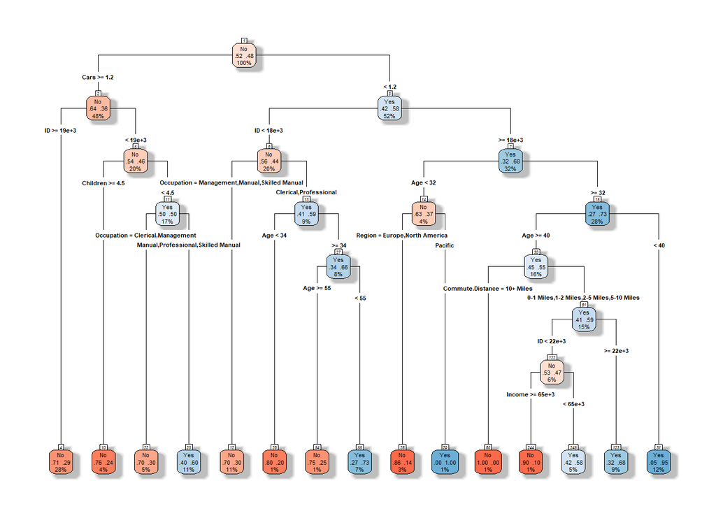

```r
rpart.plot(tree_model, type = 4, extra = 104, fallen.leaves = TRUE,
           box.palette = "RdBu", shadow.col = "gray", nn = TRUE )
```

```r
tree_predictions <- predict(tree_model, test_data, type = "class")

conf_matrix <- table(Predicted = tree_predictions, Actual = test_data$`Purchased.Bike`)
conf_matrix
```

```
##          Actual
## Predicted No Yes
##       No  98  71
##       Yes 54  77
```

```r
accuracy <- mean(tree_predictions == test_data$`Purchased.Bike`)
cat("Dokładność modelu drzewa decyzyjnego:", round(accuracy * 100, 2), "%\n")
```

```
## Dokładność modelu drzewa decyzyjnego: 58.33 %
```

# Segmentacja klientów (Klasteryzacja K-średnich) dla osób które kupiły rower ze względu na dane numeryczne

Przeprowadzono segmentację klientów, którzy kupili rower, wykorzystując metodę K-średnich na podstawie numerycznych cech. Dane zostały standaryzowane, a optymalną liczbę klastrów określono metodą WSS (Elbow Method). Klasteryzacja podzieliła klientów na trzy grupy, co wizualizacja przedstawia jako odrębne segmenty. Analiza ta pozwala lepiej zrozumieć różnice między kupującymi oraz identyfikować ich charakterystyczne cechy, co może być użyteczne w strategiach marketingowych i sprzedażowych.

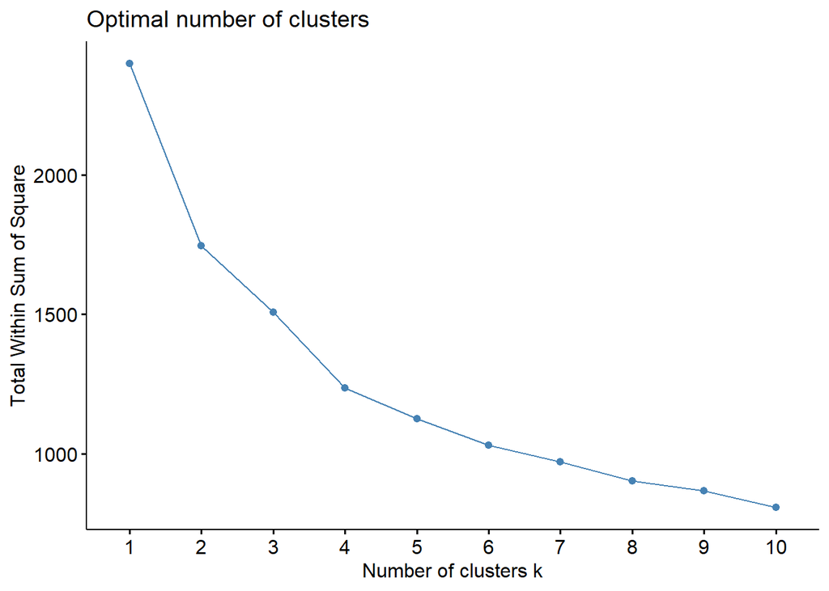

```r
bike_buyers <- sklep_rowerowy %>% filter(Purchased.Bike == "Yes")

cluster_data <- bike_buyers %>% select(where(is.numeric))
cluster_data_scaled <- scale(cluster_data)

fviz_nbclust(cluster_data_scaled, kmeans, method = "wss")
```

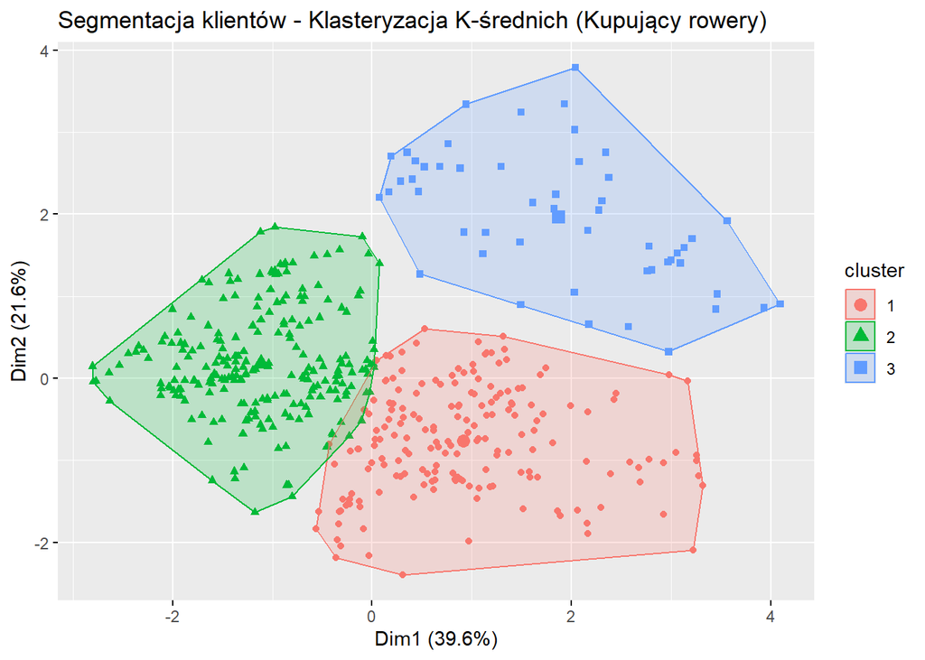

```r
set.seed(123)
kmeans_model <- kmeans(cluster_data_scaled, centers = 3, nstart = 25)

fviz_cluster(kmeans_model, data = cluster_data_scaled, geom = "point") +
  labs(title = "Segmentacja klientów - Klasteryzacja K-średnich (Kupujący rowery)")
```